# Analysis_logbook - experiment 1

# 2. Encontrar máxima estrutura que convirja

Aqui, encontrar a estrutura máxima do modelo que convirja. Há uma série de algoritmos para isso, incluindo a heurística “keep it maximal” de Barr et al. (2013) e variações. Neste experimento, utilizamos o pacote buildmer (Voeten 2022), que automatiza esse processo. Em outro documento, comparamos o desempenho do buildmer com as heurísticas manuais e observamos que os resultados são qualitativamente idênticos.

```r
fplmm <- buildmer(formula = logRT ~ foreperiod*condition*oneBackFP +
                    (1+foreperiod*condition*oneBackFP|ID),
                  data = goData2,
                  buildmerControl = list(crit = "LRT",
                                         family = gaussian(link = "identity"),
                                         include = ~ foreperiod * condition * oneBackFP,
                                         calc.anova = TRUE))
```

|  | grouping | term | block | score | Iteration | LRT |
| --- | --- | --- | --- | --- | --- | --- |
| 1 | NA | 1 | NA | NA | 1 | NA |
| 2 | NA | foreperiod | NA | NA | 1 | NA |
| 3 | NA | condition | NA | NA | 1 | NA |
| 4 | NA | foreperiod:condition | NA | NA | 1 | NA |
| 5 | NA | oneBackFP | NA | NA | 1 | NA |
| 6 | NA | foreperiod:oneBackFP | NA | NA | 1 | NA |
| 7 | NA | condition:oneBackFP | NA | NA | 1 | NA |
| 8 | NA | foreperiod:condition:oneBackFP | NA | NA | 1 | NA |
| 9 | ID | 1 | NA ID 1 | -Inf | 1 | NA |
| 11 | ID | condition | NA ID condition | -241.645 | 1 | 1.134726e-105 |

```r
formula(fplmm)
```

```
logRT ~ 1 + foreperiod + condition + foreperiod:condition + oneBackFP +
    foreperiod:oneBackFP + condition:oneBackFP + foreperiod:condition:oneBackFP +
    (1 + condition | ID)
```

# 3. Compare log-transform to log-link function

```r
fplmm <- mixed(formula = logRT ~ 1 + foreperiod + condition + foreperiod:condition + oneBackFP +
                 foreperiod:oneBackFP + condition:oneBackFP + foreperiod:condition:oneBackFP +
                 (1 + condition | ID),
               data=goData2,
               control = lmerControl(optimizer = c("bobyqa"),optCtrl=list(maxfun=2e5),calc.derivs = FALSE),
               progress = TRUE,
               expand_re = FALSE,
               method =  'KR',
               REML=TRUE,
               return = "merMod")

fpglmm <- mixed(formula = RT ~ 1 + foreperiod + condition + foreperiod:condition + oneBackFP +
                 foreperiod:oneBackFP + condition:oneBackFP + foreperiod:condition:oneBackFP +
                 (1 + condition | ID),
               data=goData2,
               family = gaussian(link = "log"),
               control = glmerControl(optimizer = c("bobyqa"),optCtrl=list(maxfun=2e5),calc.derivs = FALSE),
               progress = TRUE,
               expand_re = FALSE,
               method =  'LRT',
               return = "merMod")
```

```r
anova(fplmm)
```

```
Type III Analysis of Variance Table with Satterthwaite's method
                                Sum Sq Mean Sq NumDF  DenDF  F value    Pr(>F)
foreperiod                     1.56491 0.78245     2 8028.2 159.8730 < 2.2e-16 ***
condition                      0.01355 0.01355     1   34.0   2.7690   0.10530
oneBackFP                      0.52965 0.26483     2 8029.0  54.1102 < 2.2e-16 ***
foreperiod:condition           0.17851 0.08926     2 8028.2  18.2370 1.252e-08 ***
foreperiod:oneBackFP           0.47959 0.11990     4 8032.4  24.4980 < 2.2e-16 ***
condition:oneBackFP            0.00280 0.00140     2 8028.9   0.2865   0.75087
foreperiod:condition:oneBackFP 0.05554 0.01388     4 8032.1   2.8369   0.02299 *
---
Signif. codes:  0 ‘***’ 0.001 ‘**’ 0.01 ‘*’ 0.05 ‘.’ 0.1 ‘ ’ 1
```

```r
fpglmm <- mixed(formula = RT ~ 1 + foreperiod + condition + foreperiod:condition + oneBackFP +
                 foreperiod:oneBackFP + condition:oneBackFP + foreperiod:condition:oneBackFP +
                 (1 + condition | ID),
               data=goData2,
               family = gaussian(link = "log"),
               control = glmerControl(optimizer = c("bobyqa"),optCtrl=list(maxfun=2e5),calc.derivs = FALSE),
               progress = TRUE,
               expand_re = FALSE,
               method =  'PB',
               return = "merMod")
```

```
Contrasts set to contr.sum for the following variables: foreperiod, condition, oneBackFP, ID
```

```r
?simulateResiduals


anova(fpglmm)
```

```
Analysis of Variance Table
                               npar  Sum Sq Mean Sq  F value
foreperiod                        2 1.34030 0.67015 153.4907
condition                         1 0.03887 0.03887   8.9029
oneBackFP                         2 0.40755 0.20377  46.6721
foreperiod:condition              2 0.16299 0.08150  18.6656
foreperiod:oneBackFP              4 0.29682 0.07421  16.9960
condition:oneBackFP               2 0.00313 0.00157   0.3585
foreperiod:condition:oneBackFP    4 0.03005 0.00751   1.7207
```

```r
library(DHARMa)

simulation_lmm <- simulateResiduals(fittedModel = fplmm, n = 1000, plot = F)
```

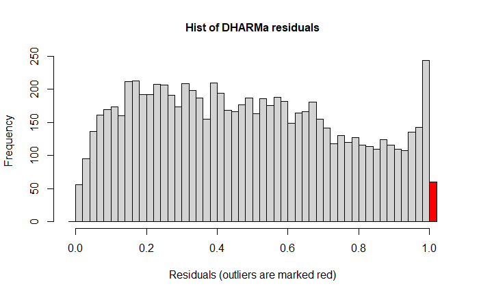

```r
# Histogram
hist(simulation_lmm)
```

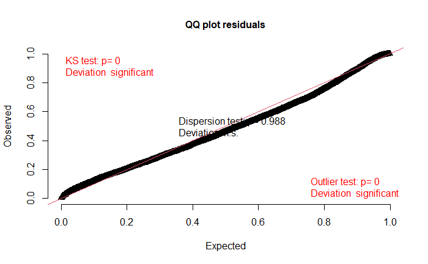

```r
# QQ-plots
plotQQunif(simulation_lmm)
```

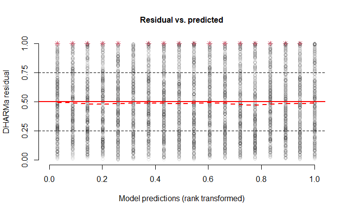

```r
# Residuals vs fitted values
plotResiduals(simulation_lmm)
```

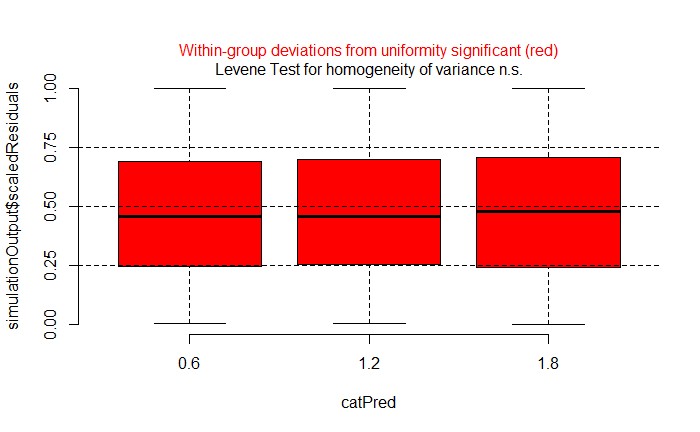

```r
# Against foreperiod
plotResiduals(simulation_lmm, form = goData2$foreperiod)
```

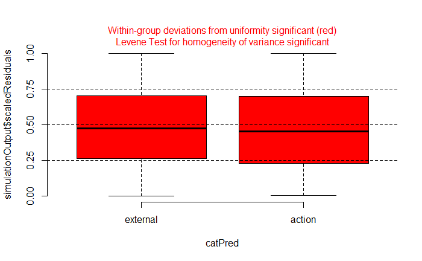

```r
# Against condition
plotResiduals(simulation_lmm, form = goData2$condition)
```

```r
simulation_glmm <- simulateResiduals(fittedModel = fpglmm, n = 1000, plot = F)
```

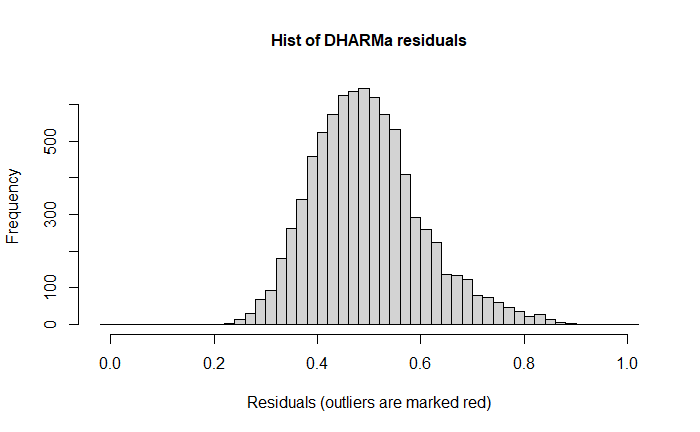

```r
# Histogram
hist(simulation_glmm)
```

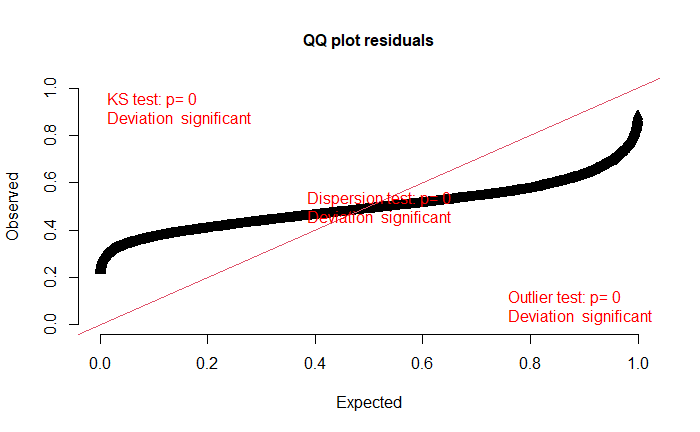

```r
# QQ-plots
plotQQunif(simulation_glmm)
```

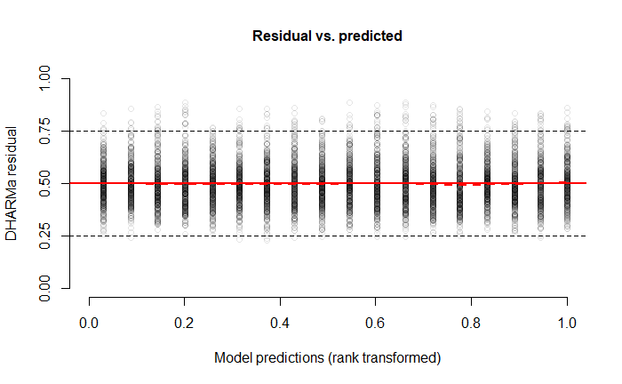

```r
# Residuals vs fitted values
plotResiduals(simulation_glmm)
```

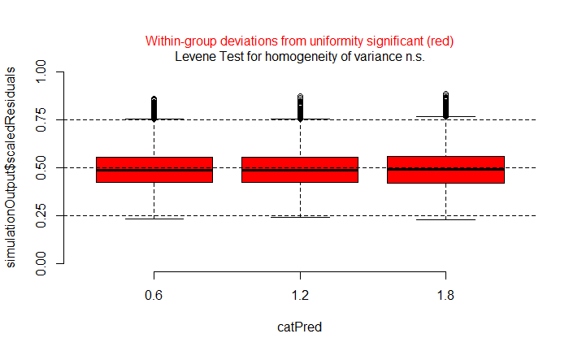

```r
# Against foreperiod
plotResiduals(simulation_glmm, form = goData2$foreperiod)
```

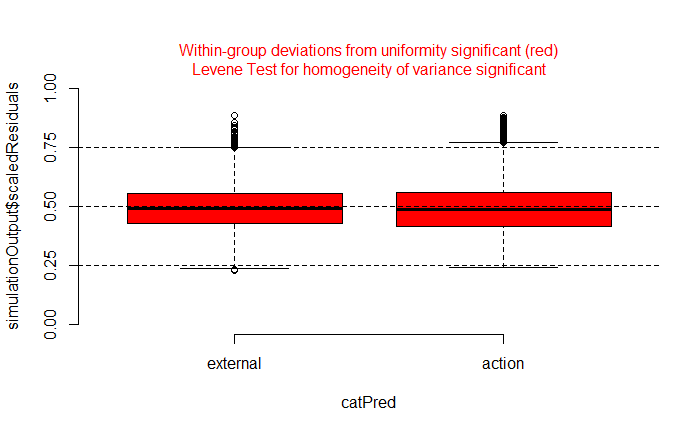

```r
# Against condition
plotResiduals(simulation_glmm, form = goData2$condition)
```

The lmm model evidently behaves much better.